# Reproducible Research Project 1

### Data For the Analysis

The data can be downloaded from the course web site:  
**Dataset**: [Activity Monitoring Data](https://d396qusza40orc.cloudfront.net/repdata%2Fdata%2Factivity.zip)  
The variables included in this dataset are:  
**steps**: Number of steps taking in a 5-minute interval (missing values are coded as NA)

**date**: The date on which the measurement was taken in YYYY-MM-DD format

**interval**: Identifier for the 5-minute interval in which measurement was taken

The dataset is stored in a comma-separated-value (CSV) file and there are a total of 17,568 observations in this dataset.

### Loading and preprocessing the data

```r
data <- read.csv('repdata_data_activity/activity.csv')
data$date <- as.Date(data$date)
data$day <- format(data$date, '%a')
```

### The total number of steps taken per day

```r
library(reshape2)
melted_data <- melt(data, id=c('date', 'interval', 'day'))
mean_steps_day <- dcast(melted_data, date~variable, sum, na.rm=T)
```

The histogram of the total number of steps taken each day.

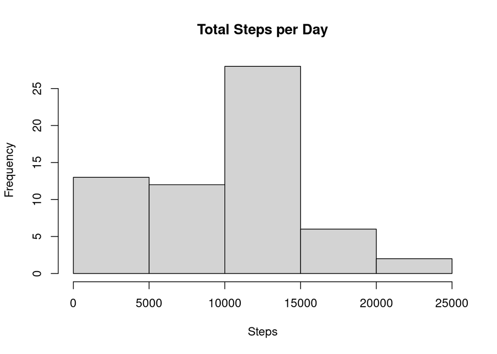

```r
hist(mean_steps_day$steps,xlab="Steps", main = "Total Steps per Day")
```

To calculate the mean and median of the total number of steps taken per day

```r
avg <- round(mean(mean_steps_day$steps, na.rm = T), digits=2)
med <- median(mean_steps_day$steps, na.rm = T)
```

the mean is 9354.23 and the median is 10395.

A time series plot of the 5-minute interval (x-axis) and the average number of steps taken, averaged across all days (y-axis)

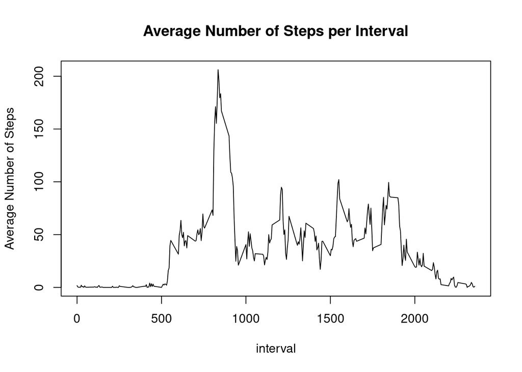

```r
interval_steps <- dcast(melted_data, interval~variable, mean, na.rm=T)
with(interval_steps, plot(interval,steps, type='l',
                          ylab="Average Number of Steps",
                          main="Average Number of Steps per Interval"))
```

Which 5-minute interval, on average across all the days in the dataset, contains the maximum number of steps?

```r
max_interval <- interval_steps$interval[which.max(interval_steps$steps)]
```

The 5-minute interval which had the maximum number of steps was the 835 interval.

### Imputing missing values

to calculate the total number of missing values in the dataset (i.e. the total number of rows with NAs)

```r
na_rows <- nrow(data[is.na(data$steps),])
```

The total number of missing values in the dataset is 2304  
My strategy for filling in NAs will be to substitute the missing steps with the average 5-minute interval based on the day of the week.

```r
cleaned_data <- data[!is.na(data$steps),]
nas_data <- data[is.na(data$steps),]
melted_cleaned_data <- melt(cleaned_data, id=c('date', 'interval', 'day'))
casted_cleaned_data <- dcast(melted_cleaned_data, day+interval~variable, mean)
merged <- merge(nas_data,casted_cleaned_data, by=c('day','interval'))
merged <- merged[,c(5,4,2,1)]
names(merged) <- names(cleaned_data)
completed_data <- rbind(cleaned_data, merged)
```

The histogram of the total number of steps taken each day

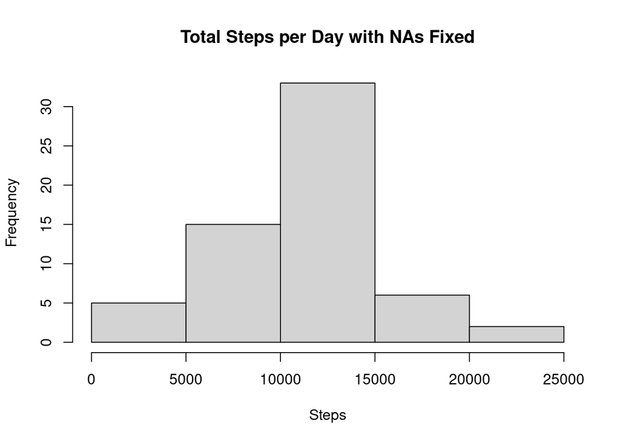

```r
melted_completed_data <- melt(completed_data, id=c('day','interval','date'))
casted_copmleted_data <- dcast(melted_completed_data,
                               date~variable, sum)
hist(casted_copmleted_data$steps, xlab="Steps", main = "Total Steps per Day with NAs Fixed")
```

To calculate and report the mean and median total number of steps taken per day

```r
avg2 <- mean(casted_copmleted_data$steps)
med2 <- median(casted_copmleted_data$steps)
```

The new mean of the imputed data is 10821.21 steps compared to the old mean of 9354.23 steps. That creates a difference of 1466.98 steps on average per day.

The new median of the imputed data is 11015 steps compared to the old median of 10395 steps. That creates a difference of 620 steps for the median.

To create a new factor variable in the dataset with two levels – “weekday” and “weekend” indicating whether a given date is a weekday or weekend day.

```r
completed_data$dayType <-
        ifelse(completed_data$day %in% c('Sat', 'Sun'),
               'Weekend', 'Weekday')
```

to make a panel plot containing a time series plot (i.e. type = “l”) of the 5-minute interval (x-axis) and the average number of steps taken, averaged across all weekday days or weekend days (y-axis)

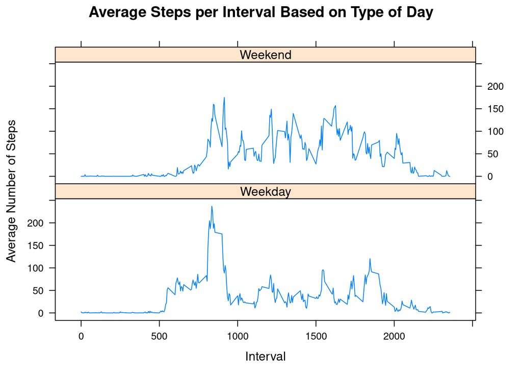

```r
library(lattice)
avg_weekdays <- melt(completed_data, id=c('day','date','dayType', 'interval'))
avg_weekdays <- dcast(avg_weekdays, dayType+interval~variable, mean)
xyplot(steps~interval|dayType, data=avg_weekdays,type='l',
        main="Average Steps per Interval Based on Type of Day",
       ylab="Average Number of Steps", xlab="Interval", layout=c(1,2))
```

Yes, the step activity trends are different based on whether the day occurs on a weekend or not. This may be due to people having an increased opportunity for activity beyond normal work hours for those who work during the week.